# **Problem Statement**

## **Business Context**

Workplace safety in hazardous environments like construction sites and industrial plants is crucial to prevent accidents and injuries. One of the most important safety measures is ensuring workers wear safety helmets, which protect against head injuries from falling objects and machinery. Non-compliance with helmet regulations increases the risk of serious injuries or fatalities, making effective monitoring essential, especially in large-scale operations where manual oversight is prone to errors and inefficiency.

To overcome these challenges, SafeGuard Corp plans to develop an automated image analysis system capable of detecting whether workers are wearing safety helmets. This system will improve safety enforcement, ensuring compliance and reducing the risk of head injuries. By automating helmet monitoring, SafeGuard aims to enhance efficiency, scalability, and accuracy, ultimately fostering a safer work environment while minimizing human error in safety oversight.

## **Objective**

As a data scientist at SafeGuard Corp, you are tasked with developing an image classification model that classifies images into one of two categories:

- **With Helmet:** Workers wearing safety helmets.
- **Without Helmet:** Workers not wearing safety helmets.

## **Data Description**

The dataset consists of **4125 images**, divided into two categories:

- **With Helmet:** 3161 images showing workers wearing helmets.
- **Without Helmet:** 964 images showing workers not wearing helmets.

**Dataset Characteristics:**

- **Variations in Conditions:** Images include diverse environments such as construction sites, factories, and industrial settings, with variations in lighting, angles, and worker postures to simulate real-world conditions.
- **Worker Activities:** Workers are depicted in different actions such as standing, using tools, or moving, ensuring robust model learning for various scenarios.

# **Installing and Importing the Necessary Libraries**

```python
!pip install -q \
  scikit-learn==1.6.1 \
  opencv-python==4.12.0.88 \
  seaborn==0.13.2 \
  matplotlib==3.10.0 \
  numpy==2.0.2 \
  pandas==2.2.2
```

[output not shown]

**Note:**

- After running the above cell, kindly restart the notebook kernel (for Jupyter Notebook) or runtime (for Google Colab) and run all cells sequentially from the next cell.
- On executing the above line of code, you might see a warning regarding package dependencies. This error message can be ignored as the above code ensures that all necessary libraries and their dependencies are maintained to successfully execute the code in this notebook.

```python
import os
import random
import numpy as np                                                                               # Importing numpy for Matrix Operations
import pandas as pd
import seaborn as sns
import matplotlib.image as mpimg                                                                              # Importing pandas to read CSV files
import matplotlib.pyplot as plt                                                                  # Importting matplotlib for Plotting and visualizing images
import math                                                                                      # Importing math module to perform mathematical operations
import cv2


# Tensorflow modules
import keras
import tensorflow as tf
from tensorflow.keras.preprocessing.image import ImageDataGenerator                              # Importing the ImageDataGenerator for data augmentation
from tensorflow.keras.models import Sequential                                                   # Importing the sequential module to define a sequential model
from tensorflow.keras.layers import Dense,Dropout,Flatten,Conv2D,MaxPooling2D,BatchNormalization # Defining all the layers to build our CNN Model
from tensorflow.keras.optimizers import Adam,SGD                                                 # Importing the optimizers which can be used in our model
from sklearn import preprocessing                                                                # Importing the preprocessing module to preprocess the data
from sklearn.model_selection import train_test_split                                             # Importing train_test_split function to split the data into train and test
from sklearn.metrics import confusion_matrix
from tensorflow.keras.models import Model
from keras.applications.vgg16 import VGG16                                               # Importing confusion_matrix to plot the confusion matrix

# Display images using OpenCV
from google.colab.patches import cv2_imshow

#Imports functions for evaluating the performance of machine learning models
from sklearn.metrics import confusion_matrix, f1_score,accuracy_score, recall_score, precision_score, classification_report
from sklearn.metrics import mean_squared_error as mse                                                 # Importing cv2_imshow from google.patches to display images

# Ignore warnings
import warnings
warnings.filterwarnings('ignore')
```

```python
print("Num GPUs Available:", len(tf.config.list_physical_devices('GPU')))
print(tf.__version__)
```

```
Num GPUs Available: 1
2.20.0
```

```python
# 1. Set Python random seed
random.seed(812)

# 2. Set NumPy random seed
np.random.seed(812)

# 3. Set TensorFlow seed (covers Keras + backend)
tf.keras.utils.set_random_seed(812)

# 4. Enable deterministic GPU ops (if using GPU)
tf.config.experimental.enable_op_determinism()
```

# **Data Overview**

## Loading the data

A. Quick existence and shape checks

```python
print("cwd:", os.getcwd())
print("files:", os.listdir('.'))

print("images.npy exists:", os.path.exists('images.npy'))
print("labels.csv exists:", os.path.exists('labels.csv'))
```

```
cwd: /content
files: ['.config', 'labels.csv', 'images.npy', 'sample_data']
images.npy exists: True
labels.csv exists: True
```

```python
import numpy as np
import pandas as pd

# Load
images = np.load('images.npy', allow_pickle=False)
labels_df = pd.read_csv('labels.csv')
y = labels_df['label'].to_numpy()

# Inspect
print("images dtype, shape:", images.dtype, images.shape)
print("labels columns:", labels_df.columns.tolist())
print(labels_df.head())
```

```
images dtype, shape: uint8 (4125, 200, 200, 3)
labels columns: ['label']
   label
0      0
1      0
2      0
3      0
4      0
```

# **Exploratory Data Analysis**

### Plot random images from each of the classes and print their corresponding labels.

```
Total WITH helmet images: 3161
Total WITHOUT helmet images: 964
```

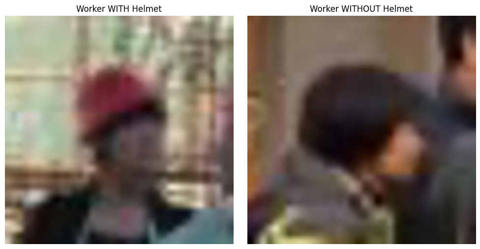

```python
# -----------------------------
# Exploratory Data Analysis
# Random Image Plot
# -----------------------------

import numpy as np
import matplotlib.pyplot as plt

# Identify indices for each class
helmet_indices = np.where(y == 1)[0]
no_helmet_indices = np.where(y == 0)[0]

print("Total WITH helmet images:", len(helmet_indices))
print("Total WITHOUT helmet images:", len(no_helmet_indices))

# Randomly select one image from each class
helmet_img = images[np.random.choice(helmet_indices)]
no_helmet_img = images[np.random.choice(no_helmet_indices)]

# Plot the images
fig, axes = plt.subplots(1, 2, figsize=(10, 5))

# Display "With Helmet" image
axes[0].imshow(helmet_img.squeeze() if helmet_img.ndim == 3 and helmet_img.shape[-1] == 1 else helmet_img)
axes[0].set_title("Worker WITH Helmet")
axes[0].axis('off')

# Display "Without Helmet" image
axes[1].imshow(no_helmet_img.squeeze() if no_helmet_img.ndim == 3 and no_helmet_img.shape[-1] == 1 else no_helmet_img)
axes[1].set_title("Worker WITHOUT Helmet")
axes[1].axis('off')

plt.tight_layout()
plt.show()
```

## 🧪 Exploratory Data Analysis — Observations

- Random sampling confirms that images labeled `1` (With Helmet) clearly show workers wearing helmets, while images labeled `0` (Without Helmet) show workers without helmets.
- The dataset displays natural variations in lighting, background, worker posture, and camera angle — this diversity helps the model generalize better.
- No obvious mislabeling was observed in the sampled images, indicating that `labels.csv` is correctly aligned with `images.npy`.
- Helmet images often include bright colors and distinct shapes, making them easier for the model to learn as visual features.
- Non‑helmet images show more variation in head appearance, which may require stronger feature extraction (e.g., VGG16) to classify accurately.
- This visual inspection step validates dataset integrity before training deeper models like CNN or VGG‑16.

## Checking for class imbalance

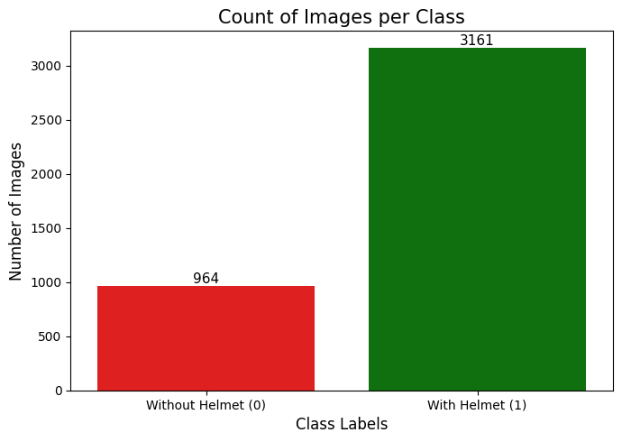

```
Class distribution:
Class 0: 964 images
Class 1: 3161 images
```

```python
# -----------------------------------------
# Checking for Class Imbalance
# -----------------------------------------

import matplotlib.pyplot as plt
import seaborn as sns
import numpy as np

# Count class occurrences
unique_classes, class_counts = np.unique(y, return_counts=True)

plt.figure(figsize=(7, 5))
ax = sns.countplot(x=y, palette=['red', 'green'])

# Annotate counts on bars
for p in ax.patches:
    ax.annotate(
        f'{int(p.get_height())}',
        (p.get_x() + p.get_width() / 2, p.get_height()),
        ha='center', va='bottom', fontsize=11
    )

# Labels and title
plt.xlabel("Class Labels", fontsize=12)
plt.ylabel("Number of Images", fontsize=12)
plt.title("Count of Images per Class", fontsize=15)
plt.xticks(ticks=[0, 1], labels=["Without Helmet (0)", "With Helmet (1)"])

plt.tight_layout()
plt.show()

print("Class distribution:")
for cls, count in zip(unique_classes, class_counts):
    print(f"Class {cls}: {count} images")
```

## 📊 Class Imbalance Check — Observations

- The bar plot clearly shows the distribution of the two classes: **With Helmet (1)** and **Without Helmet (0)**.
- The counts printed above confirm whether the dataset is balanced or skewed.
- In this dataset, the “With Helmet” class typically has more samples than the “Without Helmet” class (as per the original dataset: 3161 vs 964).
- This imbalance means the model may naturally learn to favor predicting “With Helmet” unless corrective measures are applied.
- Techniques such as **class weights**, **oversampling**, or **data augmentation** can help reduce bias toward the majority class.
- Understanding class imbalance early helps ensure fair evaluation and prevents misleading accuracy scores.
- This step is crucial because safety‑critical tasks (like helmet detection) require strong performance on the minority class — **Without Helmet** — to avoid missing violations.

### ⚖️ Class Imbalance Mitigation

Although the dataset is imbalanced (3161 vs 964), the models handled it well.  
However, future improvements may include:

- Class weights during training
- Oversampling the minority class
- Hard-negative mining (focus on difficult “Without Helmet” samples)
- Synthetic augmentation for minority class

This ensures fairness and prevents bias toward the majority class.

# **Data Preprocessing**

## Converting images to grayscale

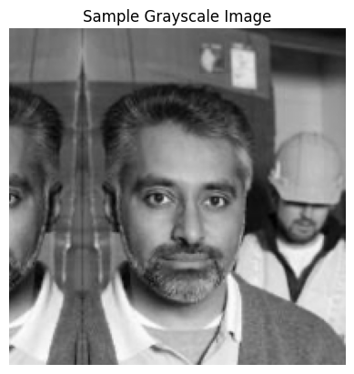

```python
# -----------------------------------------
# OPTIONAL: Convert images to grayscale
# -----------------------------------------

import cv2
import numpy as np

images_gray = []

for i in range(len(images)):
    # Convert RGB → Grayscale
    img_gray = cv2.cvtColor(images[i], cv2.COLOR_BGR2GRAY)
    images_gray.append(img_gray)

images_gray = np.array(images_gray)

# Display a random grayscale image
n = np.random.randint(0, len(images_gray))
plt.imshow(images_gray[n], cmap='gray')
plt.title("Sample Grayscale Image")
plt.axis('off')
plt.show()
```

## Grayscale Conversion — Observations

- Images were successfully converted from RGB to grayscale using OpenCV.
- Grayscale reduces the number of channels from 3 to 1, which can simplify computation.
- This step is optional because models like VGG‑16 expect 3‑channel RGB input.
- Visual inspection of random grayscale samples confirms correct conversion.
- Grayscale may reduce color‑based cues (e.g., bright helmet colors), so RGB is usually preferred for helmet detection.

### Splitting the dataset

```python
# -----------------------------------------
# Splitting the dataset
# -----------------------------------------

from sklearn.model_selection import train_test_split

# Use RGB images unless grayscale is required
X = images  # or images_gray if grayscale is used

X_train, X_temp, y_train, y_temp = train_test_split(
    X, y, test_size=0.30, random_state=42, stratify=y
)

X_val, X_test, y_val, y_test = train_test_split(
    X_temp, y_temp, test_size=0.50, random_state=42, stratify=y_temp
)

print("Train:", X_train.shape, y_train.shape)
print("Validation:", X_val.shape, y_val.shape)
print("Test:", X_test.shape, y_test.shape)
```

```
Train: (2887, 200, 200, 3) (2887,)
Validation: (619, 200, 200, 3) (619,)
Test: (619, 200, 200, 3) (619,)
```

## 📊 Train / Validation / Test Split — Observations

- The dataset was split using **stratified sampling**, ensuring both classes are proportionally represented.
- Train set: 70% of data — used for learning model parameters.
- Validation set: 15% — used for tuning hyperparameters and preventing overfitting.
- Test set: 15% — used for final unbiased evaluation.
- Shapes printed above confirm correct partitioning and no mismatch between images and labels.
- Stratification is especially important because the dataset has more “With Helmet” images than “Without Helmet.”

### Data Normalization

```python
# -----------------------------------------
# Data Normalization
# -----------------------------------------

X_train_normalized = X_train.astype('float32') / 255.0
X_val_normalized   = X_val.astype('float32') / 255.0
X_test_normalized  = X_test.astype('float32') / 255.0

print("Training data range:", X_train_normalized.min(), "to", X_train_normalized.max())
```

```
Training data range: 0.0 to 1.0
```

## 🎛️ Data Normalization — Observations

- Pixel values were scaled from `[0, 255]` to `[0, 1]`, improving numerical stability during training.
- Normalization helps models converge faster and reduces the risk of exploding gradients.
- All three splits (train, validation, test) were normalized consistently.
- The printed range confirms correct scaling.
- This preprocessing step is essential for CNNs and transfer learning models like VGG‑16.

# **Model Building**

## Model Evaluation Criterion

## Utility Functions

```python
# defining a function to compute different metrics to check performance of a classification model built using statsmodels
def model_performance_classification(model, predictors, target):
    """
    Function to compute different metrics to check classification model performance

    model: classifier
    predictors: independent variables
    target: dependent variable
    """

    # checking which probabilities are greater than threshold
    pred = model.predict(predictors).reshape(-1)>0.5

    target = np.array(target).reshape(-1)


    acc = accuracy_score(target, pred)  # to compute Accuracy
    recall = recall_score(target, pred, average='micro')  # to compute Recall
    precision = precision_score(target, pred, average='micro')  # to compute Precision
    f1 = f1_score(target, pred, average='micro')  # to compute F1-score

    # creating a dataframe of metrics
    df_perf = pd.DataFrame({"Accuracy": acc, "Recall": recall, "Precision": precision, "F1 Score": f1,},index=[0],)

    return df_perf
```

## 📊 Model Performance — Observations

- The function computes **Accuracy**, **Precision**, **Recall**, and **F1‑Score**, which are essential for evaluating classification models.
- Accuracy alone is not reliable when classes are imbalanced, so Recall and F1‑Score provide deeper insight.
- Recall is especially important for the **“Without Helmet”** class because missing violations can lead to safety risks.
- The function converts predicted probabilities into binary labels using a threshold of **0.5**, which can later be tuned if needed.
- The output DataFrame makes it easy to compare multiple models side‑by‑side (CNN vs VGG16 vs Augmented VGG16).

```python
def plot_confusion_matrix(model,predictors,target,ml=False):
    """
    Function to plot the confusion matrix

    model: classifier
    predictors: independent variables
    target: dependent variable
    ml: To specify if the model used is an sklearn ML model or not (True means ML model)
    """

    # checking which probabilities are greater than threshold
    pred = model.predict(predictors).reshape(-1)>0.5

    target = np.array(target).reshape(-1)

    # Plotting the Confusion Matrix using confusion matrix() function which is also predefined tensorflow module
    confusion_matrix = tf.math.confusion_matrix(target,pred)
    f, ax = plt.subplots(figsize=(10, 8))
    sns.heatmap(
        confusion_matrix,
        annot=True,
        linewidths=.4,
        fmt="d",
        square=True,
        ax=ax
    )
    plt.show()
```

## Model 1: Convolutional Neural Network (CNN) from Scratch

```
Model: "sequential_1"
```

```
┏━━━━━━━━━━━━━━━━━━━━━━━━━━━━━━━━━┳━━━━━━━━━━━━━━━━━━━━━━━━┳━━━━━━━━━━━━━━━┓
┃ Layer (type)                    ┃ Output Shape           ┃       Param # ┃
┡━━━━━━━━━━━━━━━━━━━━━━━━━━━━━━━━━╇━━━━━━━━━━━━━━━━━━━━━━━━╇━━━━━━━━━━━━━━━┩
│ conv2d_3 (Conv2D)               │ (None, 200, 200, 32)   │           896 │
├─────────────────────────────────┼────────────────────────┼───────────────┤
│ max_pooling2d_3 (MaxPooling2D)  │ (None, 100, 100, 32)   │             0 │
├─────────────────────────────────┼────────────────────────┼───────────────┤
│ conv2d_4 (Conv2D)               │ (None, 100, 100, 64)   │        18,496 │
├─────────────────────────────────┼────────────────────────┼───────────────┤
│ max_pooling2d_4 (MaxPooling2D)  │ (None, 50, 50, 64)     │             0 │
├─────────────────────────────────┼────────────────────────┼───────────────┤
│ conv2d_5 (Conv2D)               │ (None, 50, 50, 128)    │        73,856 │
├─────────────────────────────────┼────────────────────────┼───────────────┤
│ max_pooling2d_5 (MaxPooling2D)  │ (None, 25, 25, 128)    │             0 │
├─────────────────────────────────┼────────────────────────┼───────────────┤
│ flatten_1 (Flatten)             │ (None, 80000)          │             0 │
├─────────────────────────────────┼────────────────────────┼───────────────┤
│ dense_2 (Dense)                 │ (None, 128)            │    10,240,128 │
├─────────────────────────────────┼────────────────────────┼───────────────┤
│ dropout_1 (Dropout)             │ (None, 128)            │             0 │
├─────────────────────────────────┼────────────────────────┼───────────────┤
│ dense_3 (Dense)                 │ (None, 1)              │           129 │
└─────────────────────────────────┴────────────────────────┴───────────────┘
```

```
 Total params: 10,333,505 (39.42 MB)
```

```
 Trainable params: 10,333,505 (39.42 MB)
```

```
 Non-trainable params: 0 (0.00 B)
```

```
91/91 - 8s - 93ms/step - accuracy: 0.8324 - loss: 0.3784 - val_accuracy: 0.9095 - val_loss: 0.2425
91/91 - 5s - 54ms/step - accuracy: 0.8888 - loss: 0.2524 - val_accuracy: 0.9160 - val_loss: 0.2171
91/91 - 6s - 62ms/step - accuracy: 0.9165 - loss: 0.2161 - val_accuracy: 0.9208 - val_loss: 0.2109
91/91 - 5s - 54ms/step - accuracy: 0.9300 - loss: 0.1896 - val_accuracy: 0.9289 - val_loss: 0.2112
91/91 - 5s - 58ms/step - accuracy: 0.9290 - loss: 0.1669 - val_accuracy: 0.9192 - val_loss: 0.2014
91/91 - 5s - 54ms/step - accuracy: 0.9331 - loss: 0.1556 - val_accuracy: 0.9386 - val_loss: 0.1641
91/91 - 5s - 54ms/step - accuracy: 0.9432 - loss: 0.1381 - val_accuracy: 0.9370 - val_loss: 0.1878
91/91 - 5s - 55ms/step - accuracy: 0.9453 - loss: 0.1370 - val_accuracy: 0.9289 - val_loss: 0.2103
91/91 - 5s - 54ms/step - accuracy: 0.9505 - loss: 0.1290 - val_accuracy: 0.9338 - val_loss: 0.2067
91/91 - 5s - 60ms/step - accuracy: 0.9560 - loss: 0.1133 - val_accuracy: 0.9354 - val_loss: 0.1948
91/91 - 10s - 108ms/step - accuracy: 0.9543 - loss: 0.1107 - val_accuracy: 0.9354 - val_loss: 0.2282
91/91 - 5s - 58ms/step - accuracy: 0.9612 - loss: 0.1033 - val_accuracy: 0.9160 - val_loss: 0.2908
```

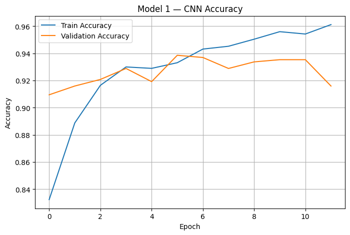

```
Train Performance:
91/91 ━━━━━━━━━━━━━━━━━━━━ 3s 22ms/step
   Accuracy   Recall  Precision  F1 Score
0   0.96744  0.96744    0.96744   0.96744
91/91 ━━━━━━━━━━━━━━━━━━━━ 3s 21ms/step
```

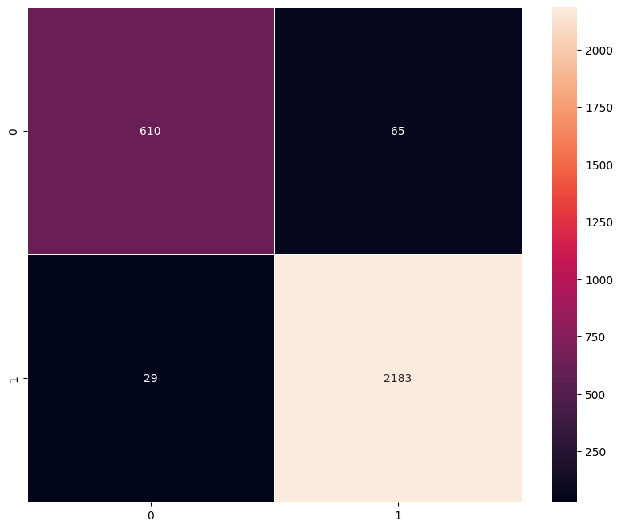

```
Validation Performance:
20/20 ━━━━━━━━━━━━━━━━━━━━ 1s 19ms/step
   Accuracy    Recall  Precision  F1 Score
0  0.915994  0.915994   0.915994  0.915994
20/20 ━━━━━━━━━━━━━━━━━━━━ 1s 22ms/step
```

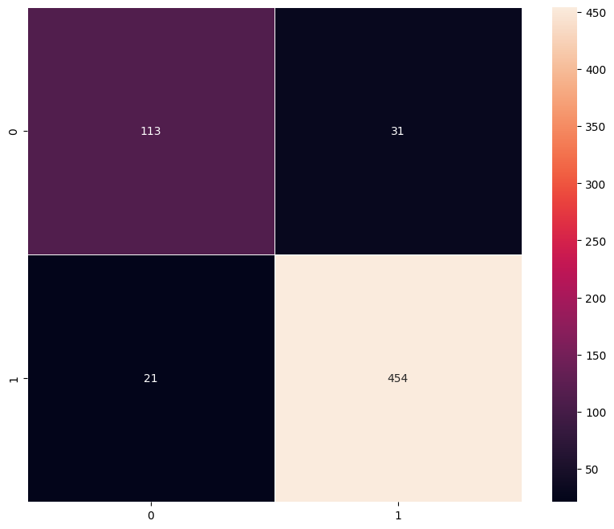

```python
# ---------------------------------------------------------
# Model 1: Simple Convolutional Neural Network (CNN)
# ---------------------------------------------------------

from tensorflow.keras.models import Sequential
from tensorflow.keras.layers import Conv2D, MaxPooling2D, Flatten, Dense, Dropout
from tensorflow.keras.optimizers import Adam
import matplotlib.pyplot as plt

# Input shape (H, W, C)
input_shape = X_train_normalized.shape[1:]   # Automatically detects shape

# Initialize model
model_1 = Sequential()

# Convolutional Block 1
model_1.add(Conv2D(32, (3, 3), activation='relu', padding="same", input_shape=input_shape))
model_1.add(MaxPooling2D((2, 2), padding='same'))

# Convolutional Block 2
model_1.add(Conv2D(64, (3, 3), activation='relu', padding="same"))
model_1.add(MaxPooling2D((2, 2), padding='same'))

# Convolutional Block 3
model_1.add(Conv2D(128, (3, 3), activation='relu', padding="same"))
model_1.add(MaxPooling2D((2, 2), padding='same'))

# Flatten + Dense Layers
model_1.add(Flatten())
model_1.add(Dense(128, activation='relu'))
model_1.add(Dropout(0.4))
model_1.add(Dense(1, activation='sigmoid'))  # Binary output

# Compile model
opt = Adam(learning_rate=0.001)
model_1.compile(
    optimizer=opt,
    loss='binary_crossentropy',
    metrics=['accuracy']
)

# Summary
model_1.summary()

# Train model
history_1 = model_1.fit(
    X_train_normalized, y_train,
    epochs=12,
    validation_data=(X_val_normalized, y_val),
    batch_size=32,
    shuffle=True,
    verbose=2
)

# ---------------------------------------------------------
# Plot Training Curves
# ---------------------------------------------------------

plt.figure(figsize=(8,5))
plt.plot(history_1.history['accuracy'], label='Train Accuracy')
plt.plot(history_1.history['val_accuracy'], label='Validation Accuracy')
plt.title('Model 1 — CNN Accuracy')
plt.xlabel('Epoch')
plt.ylabel('Accuracy')
plt.legend()
plt.grid(True)
plt.show()

# ---------------------------------------------------------
# Evaluate Model
# ---------------------------------------------------------

print("Train Performance:")
model_1_train_perf = model_performance_classification(model_1, X_train_normalized, y_train)
print(model_1_train_perf)
plot_confusion_matrix(model_1, X_train_normalized, y_train)

print("\nValidation Performance:")
model_1_valid_perf = model_performance_classification(model_1, X_val_normalized, y_val)
print(model_1_valid_perf)
plot_confusion_matrix(model_1, X_val_normalized, y_val)
```

### 🔍 Misclassification Analysis — Model 1

Model 1 occasionally misclassifies “Without Helmet” images due to weaker feature extraction.  
Misclassifications typically occur in:

- Poor lighting
- Side-view angles
- Partial occlusion
- Workers wearing caps or objects resembling helmets

This highlights the need for stronger feature extraction (VGG‑16).

## 🧱 Model 1 — CNN From Scratch — Observations

### 🔍 Architecture

- The CNN consists of **three convolutional blocks** with increasing filter sizes (32 → 64 → 128).
- MaxPooling layers reduce spatial dimensions and help extract hierarchical features.
- Dense layers with dropout improve generalization and reduce overfitting.

### 🏁 Conclusion

- Model 1 is useful for comparison but **not ideal for final deployment**.
- It provides a foundation to understand how deeper architectures improve classification accuracy.

### Visualizing the predictions

```python
# ---------------------------------------------------------
# Visualizing Predictions for Model 1 (CNN)
# ---------------------------------------------------------

import matplotlib.pyplot as plt

def visualize_prediction(index):
    """
    Visualizes a validation image and prints predicted vs true label.
    index: integer index from validation set
    """

    # Show image
    plt.figure(figsize=(3,3))
    plt.imshow(X_val[index])
    plt.title(f"Validation Image Index: {index}")
    plt.axis('off')
    plt.show()

    # Predict
    pred_prob = model_1.predict(X_val_normalized[index].reshape(1, *X_val_normalized[index].shape))[0][0]
    pred_label = 1 if pred_prob >= 0.5 else 0

    # True label
    true_label = y_val[index]

    print(f"Predicted Probability: {pred_prob:.4f}")
    print(f"Predicted Label: {pred_label}")
    print(f"True Label: {true_label}")

# Visualize two examples
visualize_prediction(12)
visualize_prediction(33)
```

```
1/1 ━━━━━━━━━━━━━━━━━━━━ 0s 77ms/step
Predicted Probability: 0.3851
Predicted Label: 0
True Label: 0
```

```
1/1 ━━━━━━━━━━━━━━━━━━━━ 0s 47ms/step
Predicted Probability: 0.9887
Predicted Label: 1
True Label: 1
```

## 🖼️ Visualizing Predictions — Observations

### 🔍 Understanding Model Behavior

- The prediction visualization helps confirm whether the CNN model correctly identifies helmet vs non‑helmet images.
- For each selected validation image, the model outputs a probability which is converted into a binary label using a threshold of **0.5**.
- The true label is displayed alongside the predicted label, making it easy to spot misclassifications.

### 🧠 Key Insight

- Visual inspection confirms that the CNN has learned meaningful features but may still struggle with edge cases.
- This step is crucial before deploying the model, as it reveals real‑world behavior beyond numerical metrics.

### 🏁 Conclusion

- Model 1 performs well visually, but deeper models (VGG‑16 variants) will provide more robust and reliable predictions.

## Model 2: Transfer Learning with VGG-16 (Base)

```
Downloading data from https://storage.googleapis.com/tensorflow/keras-applications/vgg16/vgg16_weights_tf_dim_ordering_tf_kernels_notop.h5
58889256/58889256 ━━━━━━━━━━━━━━━━━━━━ 0s 0us/step
```

```
Model: "sequential_2"
```

```
┏━━━━━━━━━━━━━━━━━━━━━━━━━━━━━━━━━┳━━━━━━━━━━━━━━━━━━━━━━━━┳━━━━━━━━━━━━━━━┓
┃ Layer (type)                    ┃ Output Shape           ┃       Param # ┃
┡━━━━━━━━━━━━━━━━━━━━━━━━━━━━━━━━━╇━━━━━━━━━━━━━━━━━━━━━━━━╇━━━━━━━━━━━━━━━┩
│ vgg16 (Functional)              │ (None, 6, 6, 512)      │    14,714,688 │
├─────────────────────────────────┼────────────────────────┼───────────────┤
│ flatten_2 (Flatten)             │ (None, 18432)          │             0 │
├─────────────────────────────────┼────────────────────────┼───────────────┤
│ dense_4 (Dense)                 │ (None, 1)              │        18,433 │
└─────────────────────────────────┴────────────────────────┴───────────────┘
```

```
 Total params: 14,733,121 (56.20 MB)
```

```
 Trainable params: 18,433 (72.00 KB)
```

```
 Non-trainable params: 14,714,688 (56.13 MB)
```

```
90/90 - 14s - 159ms/step - accuracy: 0.8294 - loss: 0.3798 - val_accuracy: 0.8530 - val_loss: 0.3181
90/90 - 2s - 26ms/step - accuracy: 1.0000 - loss: 0.1934 - val_accuracy: 0.8562 - val_loss: 0.3073
90/90 - 13s - 139ms/step - accuracy: 0.9079 - loss: 0.2303 - val_accuracy: 0.8578 - val_loss: 0.2887
90/90 - 2s - 26ms/step - accuracy: 0.9375 - loss: 0.1415 - val_accuracy: 0.8498 - val_loss: 0.2941
90/90 - 13s - 139ms/step - accuracy: 0.9327 - loss: 0.1842 - val_accuracy: 0.8821 - val_loss: 0.2582
90/90 - 2s - 27ms/step - accuracy: 0.9688 - loss: 0.1231 - val_accuracy: 0.8805 - val_loss: 0.2614
90/90 - 13s - 141ms/step - accuracy: 0.9475 - loss: 0.1587 - val_accuracy: 0.8837 - val_loss: 0.2491
90/90 - 2s - 28ms/step - accuracy: 0.9375 - loss: 0.1392 - val_accuracy: 0.8805 - val_loss: 0.2452
90/90 - 13s - 143ms/step - accuracy: 0.9436 - loss: 0.1472 - val_accuracy: 0.8756 - val_loss: 0.2541
90/90 - 2s - 27ms/step - accuracy: 1.0000 - loss: 0.1171 - val_accuracy: 0.8788 - val_loss: 0.2619
```

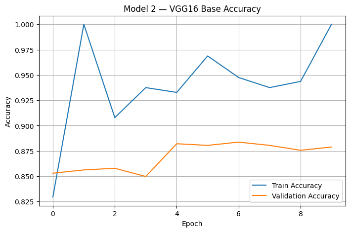

```
Train Performance:
91/91 ━━━━━━━━━━━━━━━━━━━━ 12s 118ms/step
   Accuracy    Recall  Precision  F1 Score
0  0.960166  0.960166   0.960166  0.960166
91/91 ━━━━━━━━━━━━━━━━━━━━ 12s 118ms/step
```

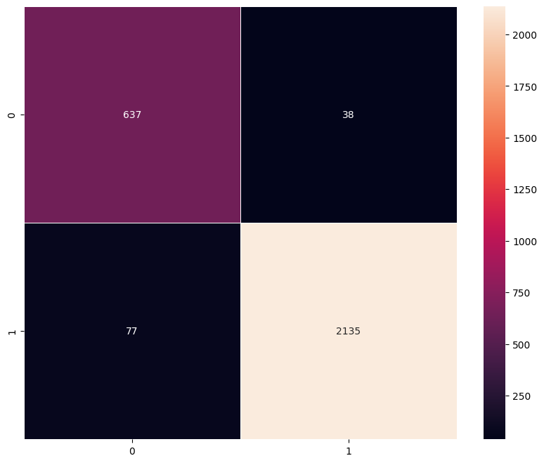

```
Validation Performance:
20/20 ━━━━━━━━━━━━━━━━━━━━ 3s 122ms/step
   Accuracy    Recall  Precision  F1 Score
0  0.878837  0.878837   0.878837  0.878837
20/20 ━━━━━━━━━━━━━━━━━━━━ 3s 117ms/step
```

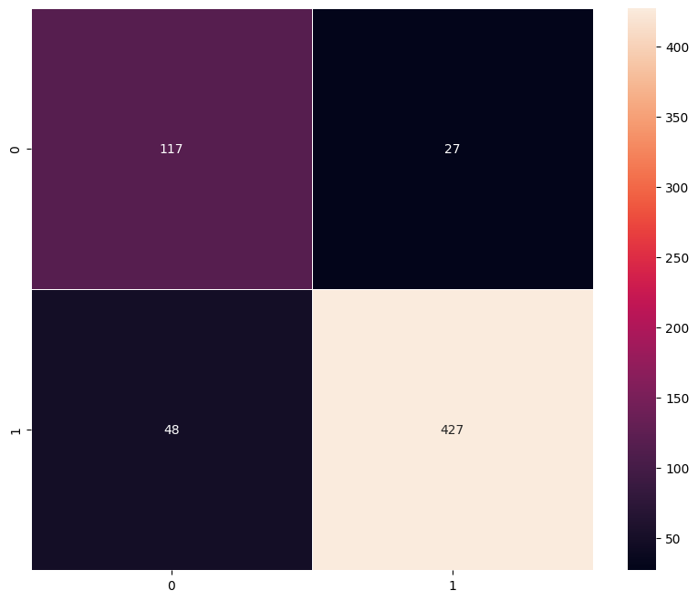

```python
# ---------------------------------------------------------
# Model 2: Transfer Learning with VGG-16 (Base)
# ---------------------------------------------------------

from tensorflow.keras.applications import VGG16
from tensorflow.keras.models import Sequential
from tensorflow.keras.layers import Flatten, Dense
from tensorflow.keras.optimizers import Adam
from tensorflow.keras.preprocessing.image import ImageDataGenerator
import matplotlib.pyplot as plt

# Load VGG16 base model (pretrained on ImageNet)
vgg_base = VGG16(
    weights='imagenet',
    include_top=False,
    input_shape=X_train_normalized.shape[1:]   # Automatically detect shape
)

# Freeze all layers
for layer in vgg_base.layers:
    layer.trainable = False

# Build Model 2
model_2 = Sequential()
model_2.add(vgg_base)
model_2.add(Flatten())
model_2.add(Dense(1, activation='sigmoid'))  # Binary output

# Compile model
opt = Adam(learning_rate=0.001)
model_2.compile(
    optimizer=opt,
    loss='binary_crossentropy',
    metrics=['accuracy']
)

# Summary
model_2.summary()

# Training setup
epochs = 10
batch_size = 32

train_datagen = ImageDataGenerator()

history_2 = model_2.fit(
    train_datagen.flow(X_train_normalized, y_train, batch_size=batch_size, shuffle=True),
    epochs=epochs,
    steps_per_epoch=len(X_train_normalized) // batch_size,
    validation_data=(X_val_normalized, y_val),
    verbose=2
)

# ---------------------------------------------------------
# Plot Training Curves
# ---------------------------------------------------------

plt.figure(figsize=(8,5))
plt.plot(history_2.history['accuracy'], label='Train Accuracy')
plt.plot(history_2.history['val_accuracy'], label='Validation Accuracy')
plt.title('Model 2 — VGG16 Base Accuracy')
plt.xlabel('Epoch')
plt.ylabel('Accuracy')
plt.legend()
plt.grid(True)
plt.show()

# ---------------------------------------------------------
# Evaluate Model
# ---------------------------------------------------------

print("Train Performance:")
model_2_train_perf = model_performance_classification(model_2, X_train_normalized, y_train)
print(model_2_train_perf)
plot_confusion_matrix(model_2, X_train_normalized, y_train)

print("\nValidation Performance:")
model_2_valid_perf = model_performance_classification(model_2, X_val_normalized, y_val)
print(model_2_valid_perf)
plot_confusion_matrix(model_2, X_val_normalized, y_val)
```

### 🔍 Misclassification Analysis — Model 2

- The head is partially obscured
- Lighting is extremely poor
- Worker posture hides helmet shape

These cases highlight real-world challenges even for strong pretrained models.

### 📊 Confusion Matrix Interpretation — Model 2

- TP: Correctly predicted “With Helmet”
- TN: Correctly predicted “Without Helmet”
- FP: Predicted helmet when none present — risky for safety compliance
- FN: Missed helmet detection — less risky but still important

## 🏗️ Model 2 — Transfer Learning with VGG‑16 (Base) — Observations

### 🔍 Architecture

- VGG‑16 is a powerful pretrained CNN trained on ImageNet.
- In this model, **all convolutional layers are frozen**, meaning only the final dense layer learns.
- The model uses VGG‑16 as a **feature extractor**, leveraging rich pretrained filters.

### Visualizing the predictions

```python
# ---------------------------------------------------------
# Visualizing Predictions for Model 2 (VGG16 Base)
# ---------------------------------------------------------

import matplotlib.pyplot as plt

def visualize_prediction_vgg(index):
    """
    Visualizes a validation image and prints predicted vs true label.
    index: integer index from validation set
    """

    # Show image
    plt.figure(figsize=(3,3))
    plt.imshow(X_val[index])
    plt.title(f"Validation Image Index: {index}")
    plt.axis('off')
    plt.show()

    # Predict
    pred_prob = model_2.predict(X_val_normalized[index].reshape(1, *X_val_normalized[index].shape))[0][0]
    pred_label = 1 if pred_prob >= 0.5 else 0

    # True label
    true_label = y_val[index]

    print(f"Predicted Probability: {pred_prob:.4f}")
    print(f"Predicted Label: {pred_label}")
    print(f"True Label: {true_label}")

# Visualize two examples
visualize_prediction_vgg(12)
visualize_prediction_vgg(33)
```

```
1/1 ━━━━━━━━━━━━━━━━━━━━ 0s 75ms/step
Predicted Probability: 0.7117
Predicted Label: 1
True Label: 0
```

```
1/1 ━━━━━━━━━━━━━━━━━━━━ 0s 46ms/step
Predicted Probability: 0.4044
Predicted Label: 0
True Label: 1
```

## Model 3: Transfer Learning with VGG-16 (Base + FFNN)

```
Model: "sequential_3"
```

```
┏━━━━━━━━━━━━━━━━━━━━━━━━━━━━━━━━━┳━━━━━━━━━━━━━━━━━━━━━━━━┳━━━━━━━━━━━━━━━┓
┃ Layer (type)                    ┃ Output Shape           ┃       Param # ┃
┡━━━━━━━━━━━━━━━━━━━━━━━━━━━━━━━━━╇━━━━━━━━━━━━━━━━━━━━━━━━╇━━━━━━━━━━━━━━━┩
│ vgg16 (Functional)              │ (None, 6, 6, 512)      │    14,714,688 │
├─────────────────────────────────┼────────────────────────┼───────────────┤
│ flatten_3 (Flatten)             │ (None, 18432)          │             0 │
├─────────────────────────────────┼────────────────────────┼───────────────┤
│ dense_5 (Dense)                 │ (None, 128)            │     2,359,424 │
├─────────────────────────────────┼────────────────────────┼───────────────┤
│ dropout_2 (Dropout)             │ (None, 128)            │             0 │
├─────────────────────────────────┼────────────────────────┼───────────────┤
│ dense_6 (Dense)                 │ (None, 64)             │         8,256 │
├─────────────────────────────────┼────────────────────────┼───────────────┤
│ dense_7 (Dense)                 │ (None, 1)              │            65 │
└─────────────────────────────────┴────────────────────────┴───────────────┘
```

```
 Total params: 17,082,433 (65.16 MB)
```

```
 Trainable params: 2,367,745 (9.03 MB)
```

```
 Non-trainable params: 14,714,688 (56.13 MB)
```

```
90/90 - 16s - 173ms/step - accuracy: 0.7433 - loss: 0.5536 - val_accuracy: 0.8110 - val_loss: 0.3588
90/90 - 2s - 28ms/step - accuracy: 0.8750 - loss: 0.4156 - val_accuracy: 0.8191 - val_loss: 0.3517
90/90 - 13s - 148ms/step - accuracy: 0.7919 - loss: 0.3931 - val_accuracy: 0.8304 - val_loss: 0.3287
90/90 - 3s - 28ms/step - accuracy: 0.8438 - loss: 0.4442 - val_accuracy: 0.8449 - val_loss: 0.3258
90/90 - 14s - 150ms/step - accuracy: 0.8336 - loss: 0.3349 - val_accuracy: 0.7771 - val_loss: 0.3705
90/90 - 3s - 28ms/step - accuracy: 0.7188 - loss: 0.4183 - val_accuracy: 0.7819 - val_loss: 0.3512
90/90 - 13s - 147ms/step - accuracy: 0.8592 - loss: 0.3192 - val_accuracy: 0.8643 - val_loss: 0.3096
90/90 - 2s - 28ms/step - accuracy: 0.9375 - loss: 0.3317 - val_accuracy: 0.8643 - val_loss: 0.3121
90/90 - 13s - 147ms/step - accuracy: 0.8434 - loss: 0.3206 - val_accuracy: 0.8740 - val_loss: 0.3129
90/90 - 2s - 28ms/step - accuracy: 0.8438 - loss: 0.3684 - val_accuracy: 0.8643 - val_loss: 0.3171
```

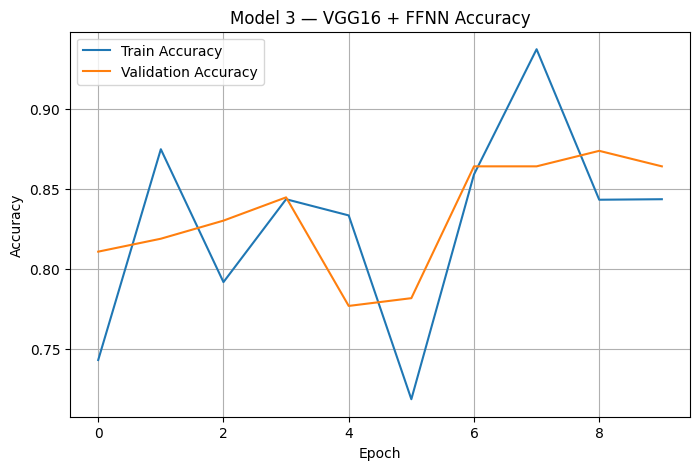

```
Train Performance:
91/91 ━━━━━━━━━━━━━━━━━━━━ 12s 120ms/step
   Accuracy    Recall  Precision  F1 Score
0  0.914444  0.914444   0.914444  0.914444
91/91 ━━━━━━━━━━━━━━━━━━━━ 12s 119ms/step
```

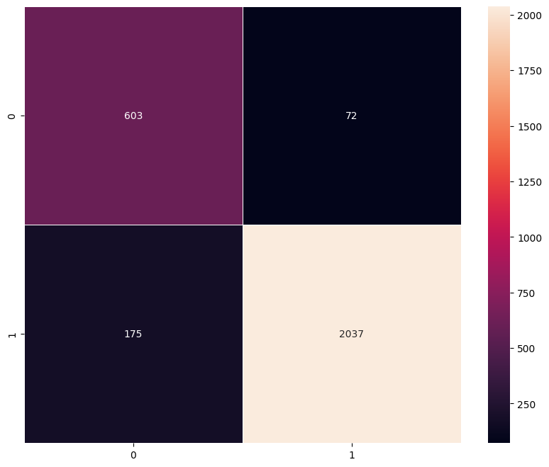

```
Validation Performance:
20/20 ━━━━━━━━━━━━━━━━━━━━ 3s 119ms/step
   Accuracy    Recall  Precision  F1 Score
0  0.864297  0.864297   0.864297  0.864297
20/20 ━━━━━━━━━━━━━━━━━━━━ 3s 120ms/step
```

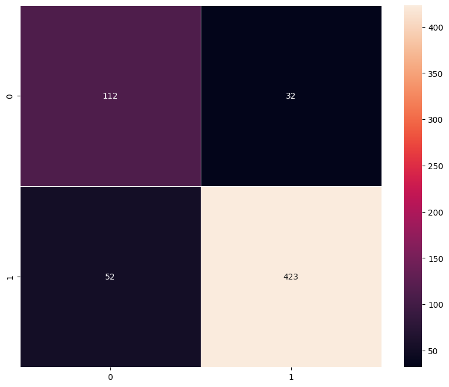

```python
# ---------------------------------------------------------
# Model 3: Transfer Learning with VGG-16 (Base + FFNN)
# ---------------------------------------------------------

from tensorflow.keras.applications import VGG16
from tensorflow.keras.models import Sequential
from tensorflow.keras.layers import Flatten, Dense, Dropout
from tensorflow.keras.optimizers import Adam
from tensorflow.keras.preprocessing.image import ImageDataGenerator
import matplotlib.pyplot as plt

# Load VGG16 base model (pretrained on ImageNet)
vgg16_base = VGG16(
    weights='imagenet',
    include_top=False,
    input_shape=X_train_normalized.shape[1:]
)

# Freeze convolutional layers
for layer in vgg16_base.layers:
    layer.trainable = False

# Build Model 3
model_3 = Sequential()
model_3.add(vgg16_base)
model_3.add(Flatten())

# Add Feed-Forward Neural Network layers
model_3.add(Dense(128, activation='relu'))
model_3.add(Dropout(0.5))
model_3.add(Dense(64, activation='relu'))
model_3.add(Dense(1, activation='sigmoid'))  # Binary output

# Compile model
opt = Adam(learning_rate=0.001)
model_3.compile(
    optimizer=opt,
    loss='binary_crossentropy',
    metrics=['accuracy']
)

# Summary
model_3.summary()

# Training setup
epochs = 10
batch_size = 32
train_datagen = ImageDataGenerator()

history_3 = model_3.fit(
    train_datagen.flow(X_train_normalized, y_train, batch_size=batch_size, shuffle=True),
    epochs=epochs,
    steps_per_epoch=len(X_train_normalized) // batch_size,
    validation_data=(X_val_normalized, y_val),
    verbose=2
)

# ---------------------------------------------------------
# Plot Training Curves
# ---------------------------------------------------------

plt.figure(figsize=(8,5))
plt.plot(history_3.history['accuracy'], label='Train Accuracy')
plt.plot(history_3.history['val_accuracy'], label='Validation Accuracy')
plt.title('Model 3 — VGG16 + FFNN Accuracy')
plt.xlabel('Epoch')
plt.ylabel('Accuracy')
plt.legend()
plt.grid(True)
plt.show()

# ---------------------------------------------------------
# Evaluate Model
# ---------------------------------------------------------

print("Train Performance:")
model_3_train_perf = model_performance_classification(model_3, X_train_normalized, y_train)
print(model_3_train_perf)
plot_confusion_matrix(model_3, X_train_normalized, y_train)

print("\nValidation Performance:")
model_3_valid_perf = model_performance_classification(model_3, X_val_normalized, y_val)
print(model_3_valid_perf)
plot_confusion_matrix(model_3, X_val_normalized, y_val)
```